# [SAP] Projektni zadatak - Analiza podataka zdravstvenog pregleda

Statistički najizglednije ime

2025-01-24

#Inicijalni koraci projekta ## Učitavanje podataka

##Filtriranje podataka

```r
# Filtriranje besmislenih podataka iz tablice
filtered_data <- healthDATA.modif %>% filter(ap_hi > 0) %>% filter(ap_lo > 0) %>% filter(ap_hi > ap_lo)

filtered_data <- filtered_data %>%
  mutate(
    cholesterol = as.factor(cholesterol),
    gender = as.factor(gender),
    AgeGroup = as.factor(AgeGroup)
  ) %>% mutate (AgeGroup = fct_relevel(AgeGroup, "20-40", "40-60", ">60"))

str(filtered_data)
head(filtered_data)
```

```
## tibble [68,709 × 18] (S3: tbl_df/tbl/data.frame)
##  $ ...1       : num [1:68709] 0 1 2 3 4 5 6 7 8 9 ...
##  $ id         : num [1:68709] 0 1 2 3 4 8 9 12 13 14 ...
##  $ age        : num [1:68709] 18393 20228 18857 17623 17474 ...
##  $ gender     : Factor w/ 2 levels "1","2": 2 1 1 2 1 1 1 2 1 1 ...
##  $ height     : num [1:68709] 168 156 165 169 156 151 157 178 158 164 ...
##  $ weight     : num [1:68709] 62 85 64 82 56 67 93 95 71 68 ...
##  $ ap_hi      : num [1:68709] 110 140 130 150 100 120 130 130 110 110 ...
##  $ ap_lo      : num [1:68709] 80 90 70 100 60 80 80 90 70 60 ...
##  $ cholesterol: Factor w/ 3 levels "1","2","3": 1 3 3 1 1 2 3 3 1 1 ...
##  $ gluc       : num [1:68709] 1 1 1 1 1 2 1 3 1 1 ...
##  $ smoke      : num [1:68709] 0 0 0 0 0 0 0 0 0 0 ...
##  $ alco       : num [1:68709] 0 0 0 0 0 0 0 0 0 0 ...
##  $ active     : num [1:68709] 1 1 0 1 0 0 1 1 1 0 ...
##  $ cardio     : num [1:68709] 0 1 1 1 0 0 0 1 0 0 ...
##  $ AgeinYr    : num [1:68709] 50 55 51 48 47 60 60 61 48 54 ...
##  $ BMI        : num [1:68709] 22 34.9 23.5 28.7 23 29.4 37.7 30 28.4 25.3 ...
##  $ BMICat     : chr [1:68709] "Normal" "Obese" "Normal" "Over Weight" ...
##  $ AgeGroup   : Factor w/ 3 levels "20-40","40-60",..: 2 2 2 2 2 2 2 3 2 2 ...
```

| ...1 | id | age | gender | height | weight | ap_hi | ap_lo | cholesterol | gluc | smoke | alco | active | cardio | AgeinYr | BMI | BMICat | AgeGroup |
| --- | --- | --- | --- | --- | --- | --- | --- | --- | --- | --- | --- | --- | --- | --- | --- | --- | --- |
| 0 | 0 | 18393 | 2 | 168 | 62 | 110 | 80 | 1 | 1 | 0 | 0 | 1 | 0 | 50 | 22.0 | Normal | 40-60 |
| 1 | 1 | 20228 | 1 | 156 | 85 | 140 | 90 | 3 | 1 | 0 | 0 | 1 | 1 | 55 | 34.9 | Obese | 40-60 |
| 2 | 2 | 18857 | 1 | 165 | 64 | 130 | 70 | 3 | 1 | 0 | 0 | 0 | 1 | 51 | 23.5 | Normal | 40-60 |
| 3 | 3 | 17623 | 2 | 169 | 82 | 150 | 100 | 1 | 1 | 0 | 0 | 1 | 1 | 48 | 28.7 | Over Weight | 40-60 |
| 4 | 4 | 17474 | 1 | 156 | 56 | 100 | 60 | 1 | 1 | 0 | 0 | 0 | 0 | 47 | 23.0 | Normal | 40-60 |
| 5 | 8 | 21914 | 1 | 151 | 67 | 120 | 80 | 2 | 2 | 0 | 0 | 0 | 0 | 60 | 29.4 | Over Weight | 40-60 |

Kao prvi korak analize provodi se filtriranje skupa podataka kako bi izbacili besmislene podatke. Izbacuju se podaci gdje su iznosi tlaka nerealni. Također se izbacuju podaci za tlak gdje je izmjereni maksimalni tlak manji od minimalnog. Izbacujemo BMI podatke koji su veći od najvećeg izmjerenog BMI u povijesti.

```r
# Filtriranje besmislenih podataka iz tablice
filtered_data <- healthDATA.modif %>% filter(ap_hi <= 370) %>% filter(ap_lo <= 360) %>% filter(ap_hi >= 40) %>% filter(ap_lo >= 0) %>% filter(ap_hi >= ap_lo) %>% filter(BMI <= 251.1)

filtered_data <- filtered_data %>%
  mutate(
    cholesterol = as.factor(cholesterol),
    gender = as.factor(gender),
    AgeGroup = as.factor(AgeGroup)
  ) %>% mutate (AgeGroup = fct_relevel(AgeGroup, "20-40", "40-60", ">60"))

str(filtered_data)
head(filtered_data)
```

```
## tibble [68,718 × 18] (S3: tbl_df/tbl/data.frame)
##  $ ...1       : num [1:68718] 0 1 2 3 4 5 6 7 8 9 ...
##  $ id         : num [1:68718] 0 1 2 3 4 8 9 12 13 14 ...
##  $ age        : num [1:68718] 18393 20228 18857 17623 17474 ...
##  $ gender     : Factor w/ 2 levels "1","2": 2 1 1 2 1 1 1 2 1 1 ...
##  $ height     : num [1:68718] 168 156 165 169 156 151 157 178 158 164 ...
##  $ weight     : num [1:68718] 62 85 64 82 56 67 93 95 71 68 ...
##  $ ap_hi      : num [1:68718] 110 140 130 150 100 120 130 130 110 110 ...
##  $ ap_lo      : num [1:68718] 80 90 70 100 60 80 80 90 70 60 ...
##  $ cholesterol: Factor w/ 3 levels "1","2","3": 1 3 3 1 1 2 3 3 1 1 ...
##  $ gluc       : num [1:68718] 1 1 1 1 1 2 1 3 1 1 ...
##  $ smoke      : num [1:68718] 0 0 0 0 0 0 0 0 0 0 ...
##  $ alco       : num [1:68718] 0 0 0 0 0 0 0 0 0 0 ...
##  $ active     : num [1:68718] 1 1 0 1 0 0 1 1 1 0 ...
##  $ cardio     : num [1:68718] 0 1 1 1 0 0 0 1 0 0 ...
##  $ AgeinYr    : num [1:68718] 50 55 51 48 47 60 60 61 48 54 ...
##  $ BMI        : num [1:68718] 22 34.9 23.5 28.7 23 29.4 37.7 30 28.4 25.3 ...
##  $ BMICat     : chr [1:68718] "Normal" "Obese" "Normal" "Over Weight" ...
##  $ AgeGroup   : Factor w/ 3 levels "20-40","40-60",..: 2 2 2 2 2 2 2 3 2 2 ...
```

| ...1 | id | age | gender | height | weight | ap_hi | ap_lo | cholesterol | gluc | smoke | alco | active | cardio | AgeinYr | BMI | BMICat | AgeGroup |
| --- | --- | --- | --- | --- | --- | --- | --- | --- | --- | --- | --- | --- | --- | --- | --- | --- | --- |
| 0 | 0 | 18393 | 2 | 168 | 62 | 110 | 80 | 1 | 1 | 0 | 0 | 1 | 0 | 50 | 22.0 | Normal | 40-60 |
| 1 | 1 | 20228 | 1 | 156 | 85 | 140 | 90 | 3 | 1 | 0 | 0 | 1 | 1 | 55 | 34.9 | Obese | 40-60 |
| 2 | 2 | 18857 | 1 | 165 | 64 | 130 | 70 | 3 | 1 | 0 | 0 | 0 | 1 | 51 | 23.5 | Normal | 40-60 |
| 3 | 3 | 17623 | 2 | 169 | 82 | 150 | 100 | 1 | 1 | 0 | 0 | 1 | 1 | 48 | 28.7 | Over Weight | 40-60 |
| 4 | 4 | 17474 | 1 | 156 | 56 | 100 | 60 | 1 | 1 | 0 | 0 | 0 | 0 | 47 | 23.0 | Normal | 40-60 |
| 5 | 8 | 21914 | 1 | 151 | 67 | 120 | 80 | 2 | 2 | 0 | 0 | 0 | 0 | 60 | 29.4 | Over Weight | 40-60 |

```r
#Analiza skupa podataka
filtered_data <- filtered_data %>%
  mutate(gender = factor(gender,
                         levels = c(1, 2),
                         labels = c("Female", "Male")))

average_weight <- filtered_data %>%
  group_by(gender) %>%
  summarise(avg_weight = mean(weight, na.rm = TRUE))

average_weight

average_height <- filtered_data %>%
  group_by(gender) %>%
  summarise(avg_height = mean(height, na.rm = TRUE))

average_height

str(filtered_data)
head(filtered_data)
```

| gender | avg_weight |
| --- | --- |
| Female | 72.47861 |
| Male | 77.17177 |

| gender | avg_height |
| --- | --- |
| Female | 161.3799 |
| Male | 169.9386 |

```
## tibble [68,718 × 18] (S3: tbl_df/tbl/data.frame)
##  $ ...1       : num [1:68718] 0 1 2 3 4 5 6 7 8 9 ...
##  $ id         : num [1:68718] 0 1 2 3 4 8 9 12 13 14 ...
##  $ age        : num [1:68718] 18393 20228 18857 17623 17474 ...
##  $ gender     : Factor w/ 2 levels "Female","Male": 2 1 1 2 1 1 1 2 1 1 ...
##  $ height     : num [1:68718] 168 156 165 169 156 151 157 178 158 164 ...
##  $ weight     : num [1:68718] 62 85 64 82 56 67 93 95 71 68 ...
##  $ ap_hi      : num [1:68718] 110 140 130 150 100 120 130 130 110 110 ...
##  $ ap_lo      : num [1:68718] 80 90 70 100 60 80 80 90 70 60 ...
##  $ cholesterol: Factor w/ 3 levels "1","2","3": 1 3 3 1 1 2 3 3 1 1 ...
##  $ gluc       : num [1:68718] 1 1 1 1 1 2 1 3 1 1 ...
##  $ smoke      : num [1:68718] 0 0 0 0 0 0 0 0 0 0 ...
##  $ alco       : num [1:68718] 0 0 0 0 0 0 0 0 0 0 ...
##  $ active     : num [1:68718] 1 1 0 1 0 0 1 1 1 0 ...
##  $ cardio     : num [1:68718] 0 1 1 1 0 0 0 1 0 0 ...
##  $ AgeinYr    : num [1:68718] 50 55 51 48 47 60 60 61 48 54 ...
##  $ BMI        : num [1:68718] 22 34.9 23.5 28.7 23 29.4 37.7 30 28.4 25.3 ...
##  $ BMICat     : chr [1:68718] "Normal" "Obese" "Normal" "Over Weight" ...
##  $ AgeGroup   : Factor w/ 3 levels "20-40","40-60",..: 2 2 2 2 2 2 2 3 2 2 ...
```

| ...1 | id | age | gender | height | weight | ap_hi | ap_lo | cholesterol | gluc | smoke | alco | active | cardio | AgeinYr | BMI | BMICat | AgeGroup |
| --- | --- | --- | --- | --- | --- | --- | --- | --- | --- | --- | --- | --- | --- | --- | --- | --- | --- |
| 0 | 0 | 18393 | Male | 168 | 62 | 110 | 80 | 1 | 1 | 0 | 0 | 1 | 0 | 50 | 22.0 | Normal | 40-60 |
| 1 | 1 | 20228 | Female | 156 | 85 | 140 | 90 | 3 | 1 | 0 | 0 | 1 | 1 | 55 | 34.9 | Obese | 40-60 |
| 2 | 2 | 18857 | Female | 165 | 64 | 130 | 70 | 3 | 1 | 0 | 0 | 0 | 1 | 51 | 23.5 | Normal | 40-60 |
| 3 | 3 | 17623 | Male | 169 | 82 | 150 | 100 | 1 | 1 | 0 | 0 | 1 | 1 | 48 | 28.7 | Over Weight | 40-60 |
| 4 | 4 | 17474 | Female | 156 | 56 | 100 | 60 | 1 | 1 | 0 | 0 | 0 | 0 | 47 | 23.0 | Normal | 40-60 |
| 5 | 8 | 21914 | Female | 151 | 67 | 120 | 80 | 2 | 2 | 0 | 0 | 0 | 0 | 60 | 29.4 | Over Weight | 40-60 |

#Zadatak 1: ##Kakva je distribucija razina kolesterola među različitim dobnim skupinama i spolovima?

```r
# Zadatak 1

distribution <- filtered_data %>%
  group_by(gender, cholesterol) %>%
  summarise(count = n(),
            percentage = n() / nrow(filtered_data) * 100)
```

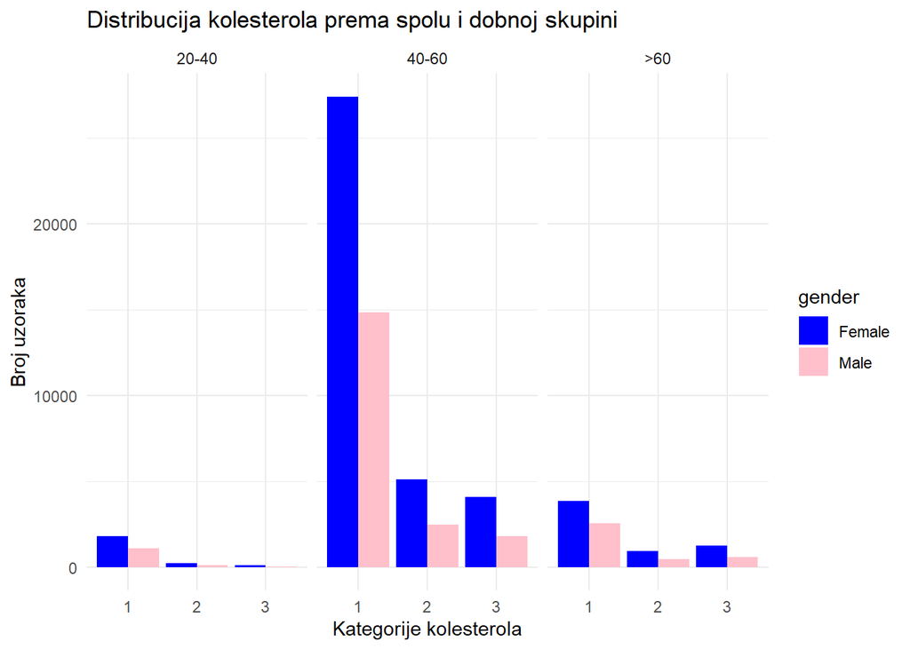

| gender | cholesterol | count | percentage |
| --- | --- | --- | --- |
| Female | 1 | 33059 | 48.108210 |
| Female | 2 | 6260 | 9.109695 |
| Female | 3 | 5440 | 7.916412 |
| Male | 1 | 18479 | 26.891062 |
| Male | 2 | 3046 | 4.432609 |
| Male | 3 | 2434 | 3.542012 |

```r
distribution

ggplot(filtered_data, aes(x = cholesterol, fill = gender)) +
  geom_bar(position = "dodge") +
  facet_wrap(~ AgeGroup) +
  labs(title = "Distribucija kolesterola prema spolu i dobnoj skupini",
       x = "Kategorije kolesterola",
       y = "Broj uzoraka") +
  theme_minimal() +
  scale_fill_manual(values = c("blue", "pink"))
```

Sljedeći grafovi prikazuju raspodjelu postotka pripadnosti trima kategorijama kolesterola (zdrav, rizičan i opasan). Svaka skupina kolesterola (označena bojama) predstavlja određeni zdravstveni status:

```
Zdrav (1) – prikazan zelenkastom bojom,
Rizičan (2) – prikazan žutom bojom,
Opasan (3) – prikazan ljubičastom bojom.
```

Prvi graf prikazuje raspodjelu unutar tri dobne skupine: 20-40 godina, 40-60 godina i iznad 60 godina.

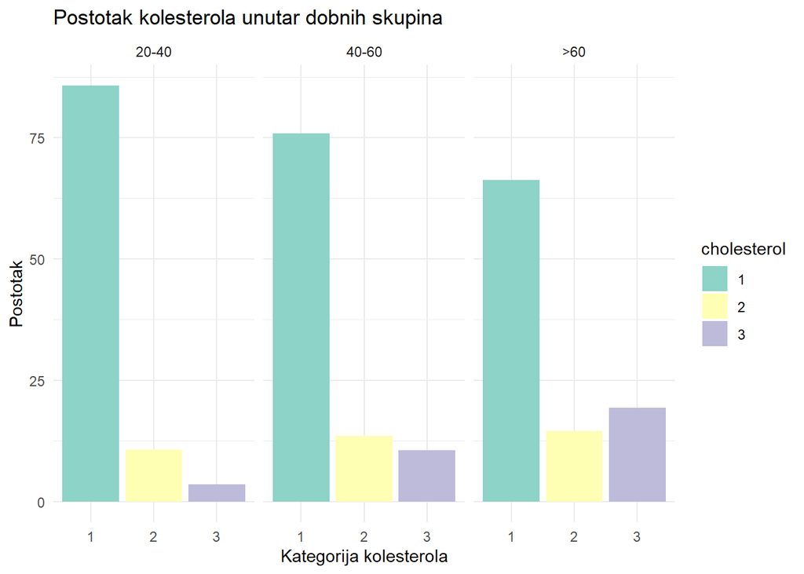

```r
cholesterol_age <- filtered_data %>%
  group_by(AgeGroup, cholesterol) %>%
  summarise(count = n(), .groups = 'drop') %>%
  group_by(AgeGroup) %>%
  mutate(percentage = count / sum(count) * 100)

ggplot(cholesterol_age, aes(x = cholesterol, y = percentage, fill = cholesterol)) +
  geom_bar(stat = "identity", position = "dodge") +
  facet_wrap(~ AgeGroup) +
  labs(title = "Postotak kolesterola unutar dobnih skupina",
       x = "Kategorija kolesterola",
       y = "Postotak") +
  theme_minimal() +
  scale_fill_brewer(palette = "Set3")
```

Zaključci sa grafa: - Zdrava kategorija dominira u svakoj dobnoj skupini. - Dobna skupina 20-40 ima najzdravije razine kolesterola, sa najmanjom zastupljenosti rizične ili opasne kategorije. - Dobna skupina iznad 60 godina, iako još uvijek teži zdravoj kategoriji kolesterola, ima češću zastupljenost rizične ili opasne kategorije od ostalih grupa. Također je jedina grupa gdje je opasna kategorija češća od rizične.

Sljedeći graf prikazuje raspodjelu unutar spolova.

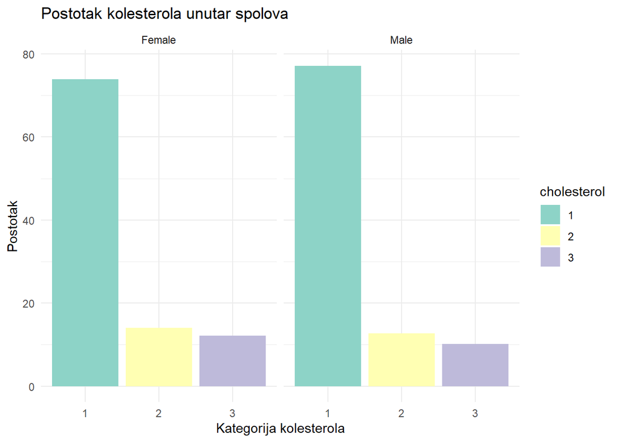

```r
cholesterol_gender <- filtered_data %>%
  group_by(gender, cholesterol) %>%
  summarise(count = n(), .groups = 'drop') %>%
  group_by(gender) %>%
  mutate(percentage = count / sum(count) * 100)

ggplot(cholesterol_gender, aes(x = cholesterol, y = percentage, fill = cholesterol)) +
  geom_bar(stat = "identity", position = "dodge") +
  facet_wrap(~ gender) +
  labs(title = "Postotak kolesterola unutar spolova",
       x = "Kategorija kolesterola",
       y = "Postotak") +
  theme_minimal() +
  scale_fill_brewer(palette = "Set3")
```

Zaključci sa grafa: - Zdrava kategorija dominira u svakom spolu. - Ne pokazuju se značajne razlike u postotnoj distribuciji kategorija kolesterola.

##Prikaz dodatnih distribucija

Sljedeći grafovi prikazuju distribucija BMI-ja. Filtrirani grafovi služe kako bi lakše vidjeli tendenciju distribucije, fokusiranjem na češće iznose.

Prvi grafovi prikazuju distribuciju BMI-ja po dobnim skupinama.

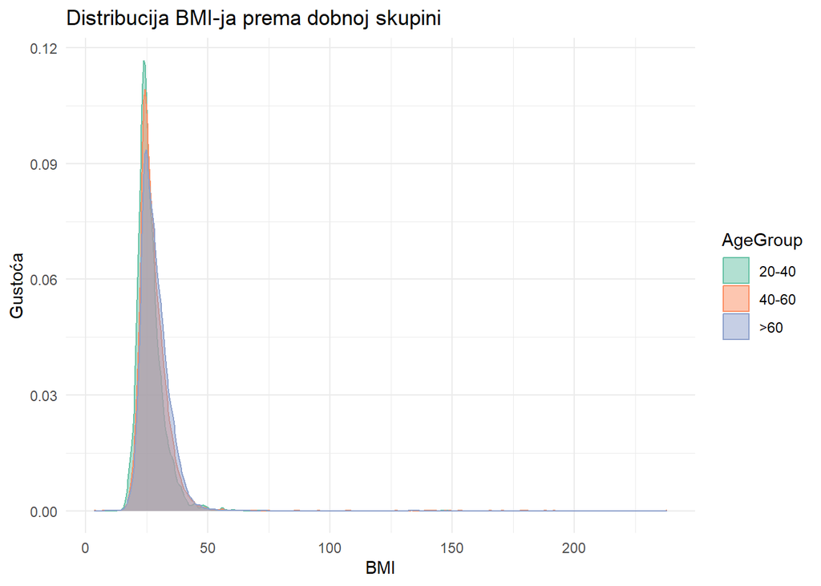

```r
BMI_filtered_data <- filtered_data %>% filter(BMI <= 60)

ggplot(filtered_data, aes(x = BMI, color = AgeGroup, fill = AgeGroup)) +
  geom_density(alpha = 0.5) +
  labs(title = "Distribucija BMI-ja prema dobnoj skupini",
       x = "BMI",
       y = "Gustoća") +
  theme_minimal() +
  scale_fill_brewer(palette = "Set2") +
  scale_color_brewer(palette = "Set2")
```

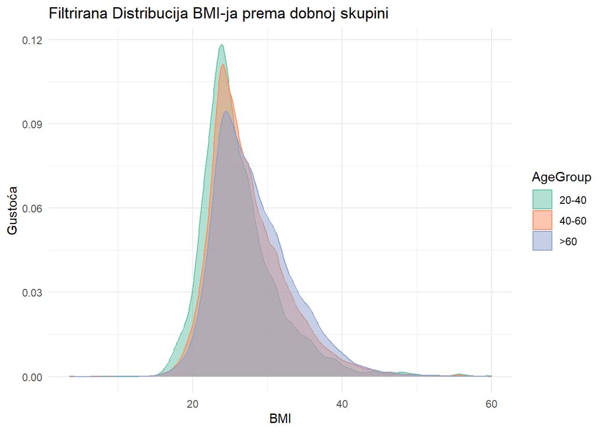

```r
ggplot(BMI_filtered_data, aes(x = BMI, color = AgeGroup, fill = AgeGroup)) +
  geom_density(alpha = 0.5) +
  labs(title = "Filtrirana Distribucija BMI-ja prema dobnoj skupini",
       x = "BMI",
       y = "Gustoća") +
  theme_minimal() +
  scale_fill_brewer(palette = "Set2") +
  scale_color_brewer(palette = "Set2")
```

Zaključak - BMI teži iznosima između 20 i 30. Postoji značajna količina podataka koja se nalazi između 30 te opada prema 40. Ostali iznosi nisu bitno reprezentirani.

Idući graf prikazuje distribuciju BMI-ja unutar spolova:

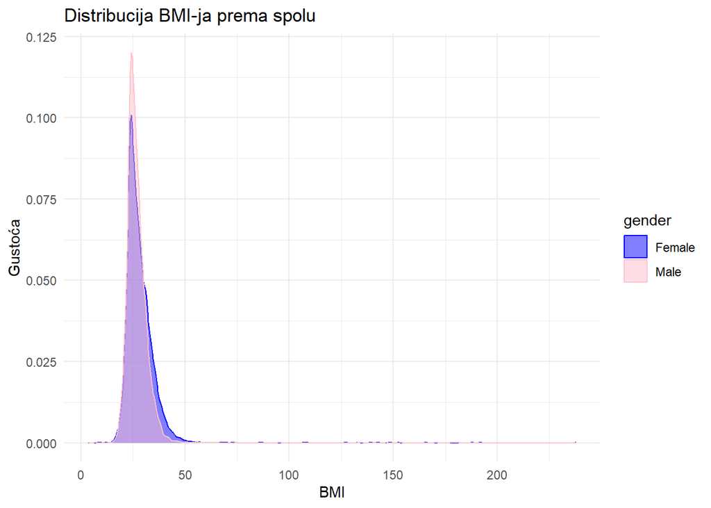

```r
ggplot(filtered_data, aes(x = BMI, color = gender, fill = gender)) +
  geom_density(alpha = 0.5) +
  labs(title = "Distribucija BMI-ja prema spolu",
       x = "BMI",
       y = "Gustoća") +
  theme_minimal() +
  scale_fill_manual(values = c("blue", "pink")) +
  scale_color_manual(values = c("blue", "pink"))
```

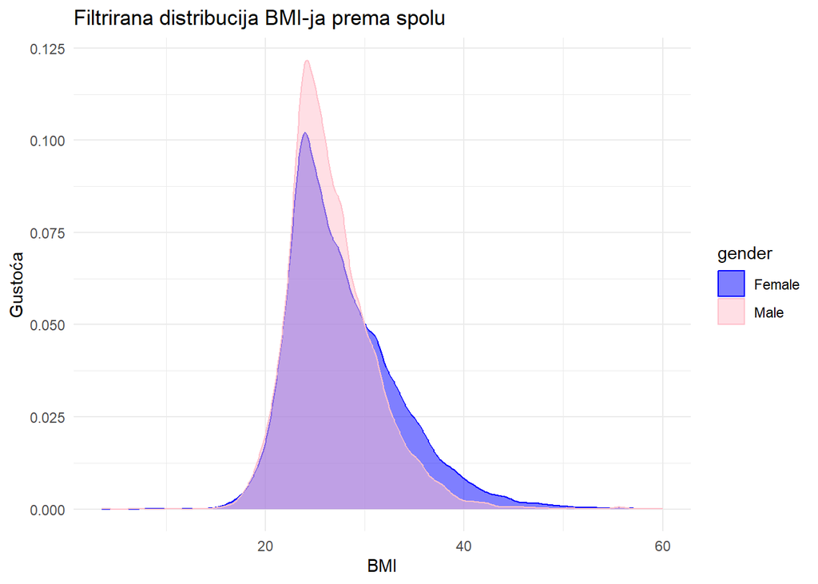

```r
ggplot(BMI_filtered_data, aes(x = BMI, color = gender, fill = gender)) +
  geom_density(alpha = 0.5) +
  labs(title = "Filtrirana distribucija BMI-ja prema spolu",
       x = "BMI",
       y = "Gustoća") +
  theme_minimal() +
  scale_fill_manual(values = c("blue", "pink")) +
  scale_color_manual(values = c("blue", "pink"))
```

Zaključak - BMI teži iznosima između 20 i 30. Postoji značajna količina podataka koja se nalazi između 30 te opada prema 40. Ostali iznosi nisu bitno reprezentirani.

Sljedeći grafovi prikazuju distribucije iznosa sistoličkog i dijastoličkog krvnog tlaka.. Filtrirani grafovi služe kako bi lakše vidjeli tendenciju distribucije, fokusiranjem na češće iznose.

Prvi grafovi prikazuju distribucije krvnog tlaka prema dobnoj skupini:

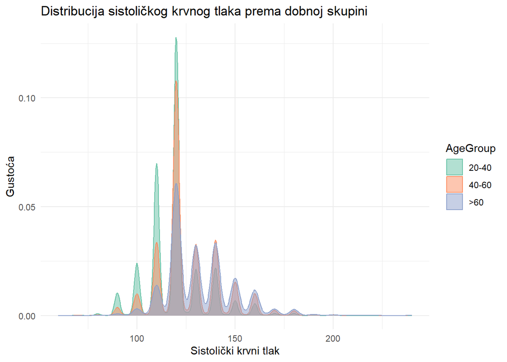

```r
ap_filtered_data <- filtered_data %>% filter(ap_hi <= 190) %>% filter(ap_lo <= 130) %>% filter(ap_hi >= 80) %>% filter(ap_lo >= 50)

ggplot(filtered_data, aes(x = ap_hi, color = AgeGroup, fill = AgeGroup)) +
  geom_density(alpha = 0.5) +
  labs(title = "Distribucija sistoličkog krvnog tlaka prema dobnoj skupini",
       x = "Sistolički krvni tlak",
       y = "Gustoća") +
  theme_minimal() +
  scale_fill_brewer(palette = "Set2") +
  scale_color_brewer(palette = "Set2")
```

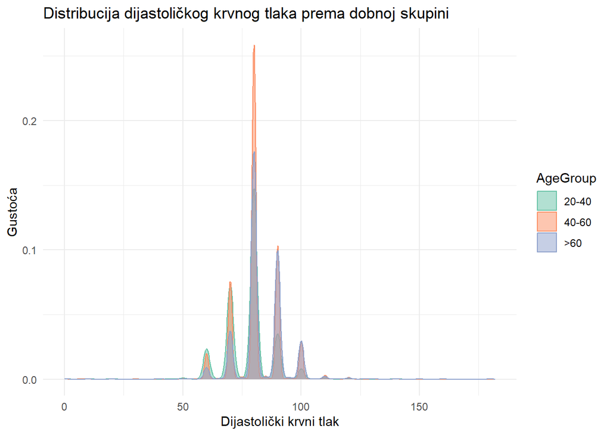

```r
ggplot(filtered_data, aes(x = ap_lo, color = AgeGroup, fill = AgeGroup)) +
  geom_density(alpha = 0.5) +
  labs(title = "Distribucija dijastoličkog krvnog tlaka prema dobnoj skupini",
       x = "Dijastolički krvni tlak",
       y = "Gustoća") +
  theme_minimal() +
  scale_fill_brewer(palette = "Set2") +
  scale_color_brewer(palette = "Set2")
```

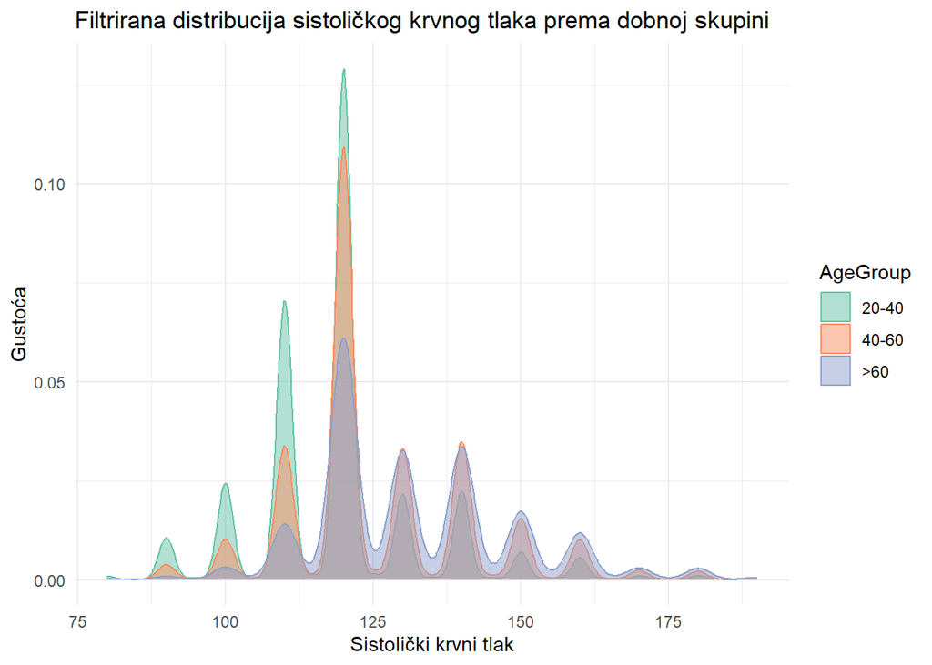

```r
ggplot(ap_filtered_data, aes(x = ap_hi, color = AgeGroup, fill = AgeGroup)) +
  geom_density(alpha = 0.5) +
  labs(title = "Filtrirana distribucija sistoličkog krvnog tlaka prema dobnoj skupini",
       x = "Sistolički krvni tlak",
       y = "Gustoća") +
  theme_minimal() +
  scale_fill_brewer(palette = "Set2") +
  scale_color_brewer(palette = "Set2")
```

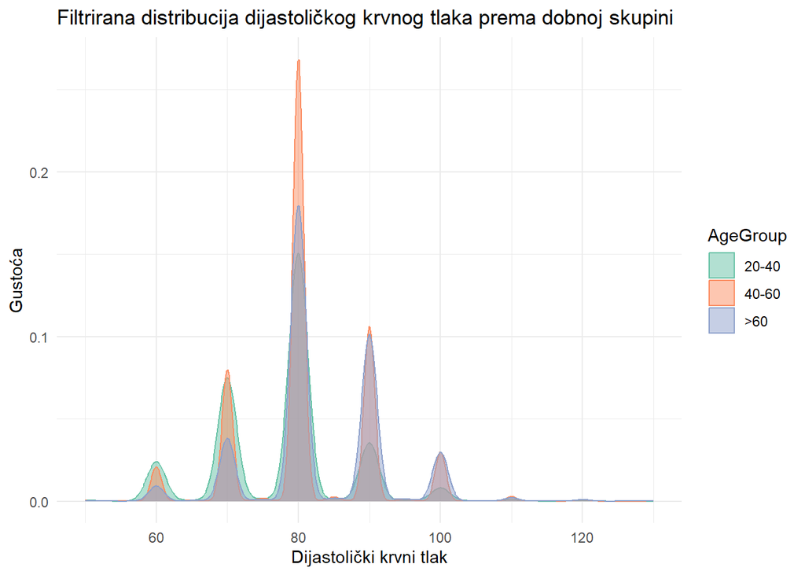

```r
ggplot(ap_filtered_data, aes(x = ap_lo, color = AgeGroup, fill = AgeGroup)) +
  geom_density(alpha = 0.5) +
  labs(title = "Filtrirana distribucija dijastoličkog krvnog tlaka prema dobnoj skupini",
       x = "Dijastolički krvni tlak",
       y = "Gustoća") +
  theme_minimal() +
  scale_fill_brewer(palette = "Set2") +
  scale_color_brewer(palette = "Set2")
```

Zaključak - Krvni tlak ima višemodalnu distribuciju. - Najčešći iznos krvnog tlaka je 120/80.

Prema spolu:

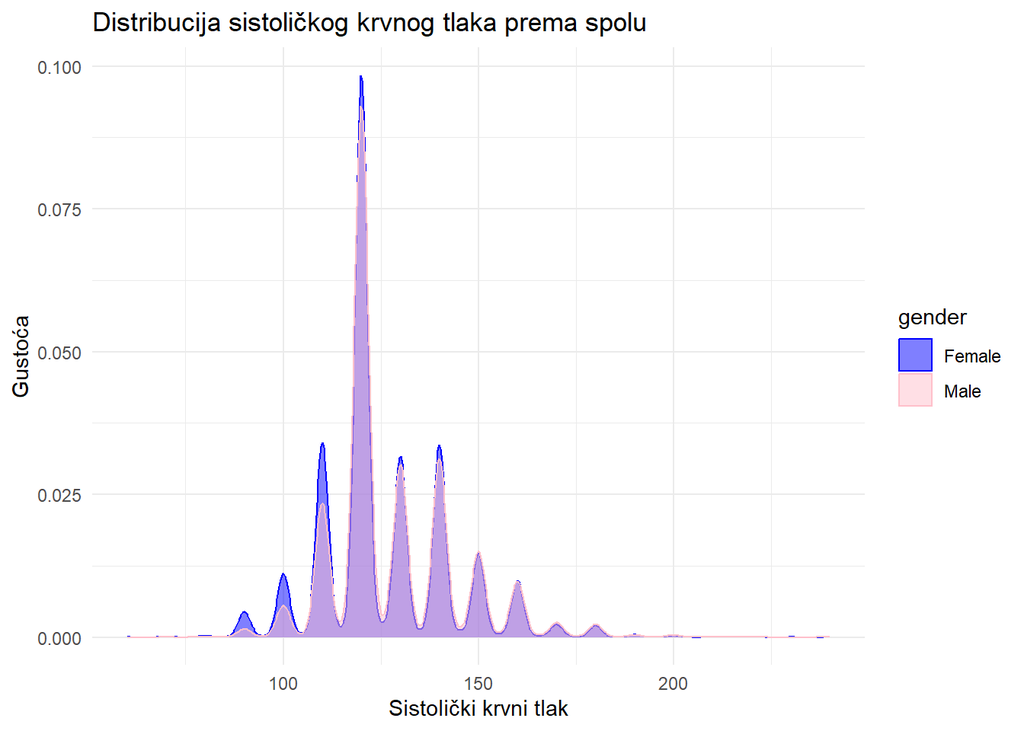

```r
ggplot(filtered_data, aes(x = ap_hi, color = gender, fill = gender)) +
  geom_density(alpha = 0.5) +
  labs(title = "Distribucija sistoličkog krvnog tlaka prema spolu",
       x = "Sistolički krvni tlak",
       y = "Gustoća") +
  theme_minimal() +
  scale_fill_manual(values = c("blue", "pink")) +
  scale_color_manual(values = c("blue", "pink"))
```

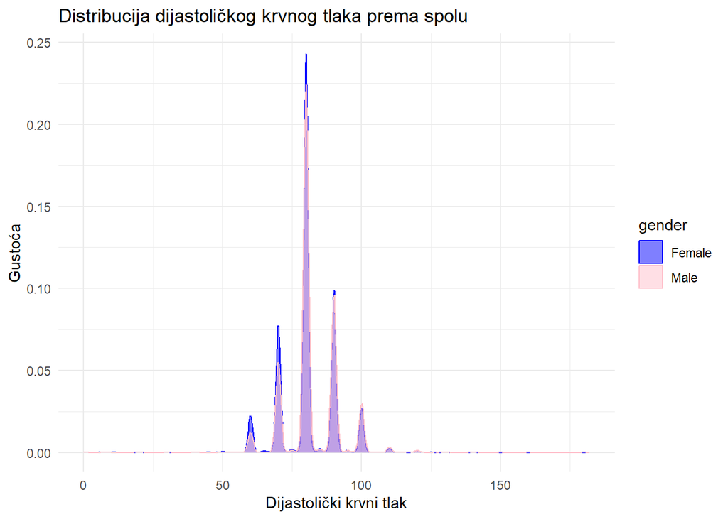

```r
ggplot(filtered_data, aes(x = ap_lo, color = gender, fill = gender)) +
  geom_density(alpha = 0.5) +
  labs(title = "Distribucija dijastoličkog krvnog tlaka prema spolu",
       x = "Dijastolički krvni tlak",
       y = "Gustoća") +
  theme_minimal() +
  scale_fill_manual(values = c("blue", "pink")) +
  scale_color_manual(values = c("blue", "pink"))
```

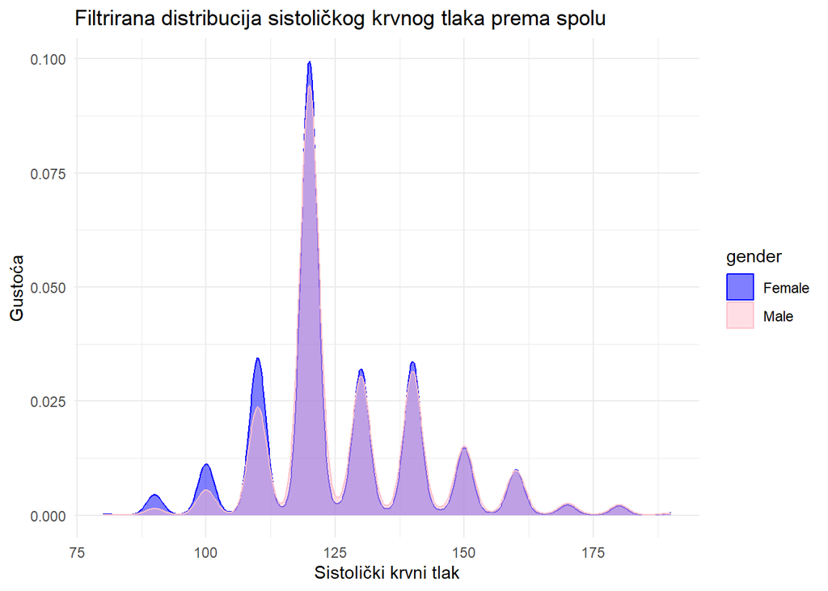

```r
ggplot(ap_filtered_data, aes(x = ap_hi, color = gender, fill = gender)) +
  geom_density(alpha = 0.5) +
  labs(title = "Filtrirana distribucija sistoličkog krvnog tlaka prema spolu",
       x = "Sistolički krvni tlak",
       y = "Gustoća") +
  theme_minimal() +
  scale_fill_manual(values = c("blue", "pink")) +
  scale_color_manual(values = c("blue", "pink"))
```

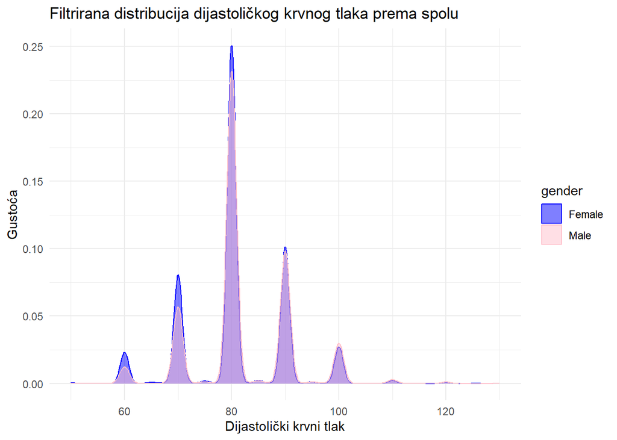

```r
ggplot(ap_filtered_data, aes(x = ap_lo, color = gender, fill = gender)) +
  geom_density(alpha = 0.5) +
  labs(title = "Filtrirana distribucija dijastoličkog krvnog tlaka prema spolu",
       x = "Dijastolički krvni tlak",
       y = "Gustoća") +
  theme_minimal() +
  scale_fill_manual(values = c("blue", "pink")) +
  scale_color_manual(values = c("blue", "pink"))
```

Zaključak - Krvni tlak ima višemodalnu distribuciju. - Najčešći iznos krvnog tlaka je 120/80.

Analizom distribucije krvnog tlaka primijetili smo da se podaci raspodjeljuju višemodalno, što intuitivno nije logično. Na primjer, zašto bi tlak od 80 bio učestaliji od tlaka 85, dok je tlak od 90 također učestaliji od 85? Objašnjenje leži u tendenciji liječnika da zaokružuju vrijednosti krvnog tlaka na brojeve koji završavaju nulom.

Kako je navedeno u dokumentu Svjetske zdravstvene organizacije (WHO) iz travnja 2020., “tehničke pogreške uzrokovane opažačem uključuju sustavne pogreške povezane s … i suboptimalno bilježenje izmjerenih vrijednosti krvnog tlaka. Primjer je ‘preferencija završnog broja’, pri čemu opažač zaokružuje izmjerene vrijednosti na preferirani broj, obično nulu.” (Izvor: WHO technical specifications for automated non-invasive blood pressure measuring devices with cuff)

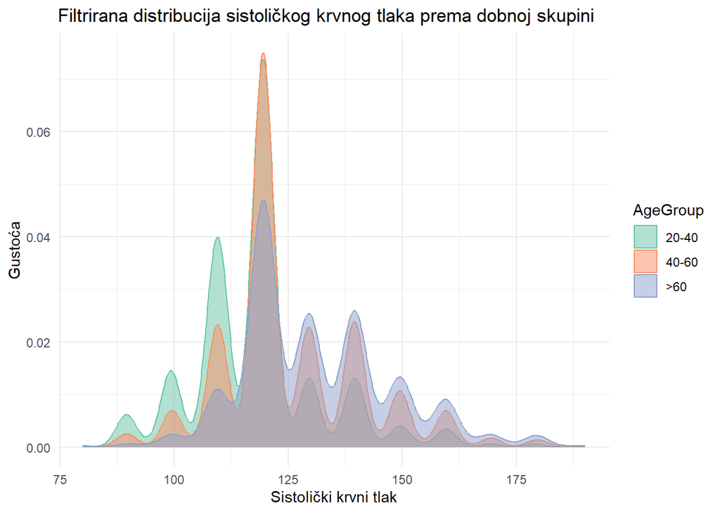

```r
set.seed(906)
filtered_data <- filtered_data %>%
  mutate(
    ap_hi = ap_hi + round(rnorm(n(), mean = -0.5, sd = 5 / 3)),
    ap_lo = ap_lo + round(rnorm(n(), mean = -0.5, sd = 5 / 3))
  )

ap_filtered_data <- filtered_data %>% filter(ap_hi <= 190) %>% filter(ap_lo <= 130) %>% filter(ap_hi >= 80) %>% filter(ap_lo >= 50)

ggplot(ap_filtered_data, aes(x = ap_hi, color = AgeGroup, fill = AgeGroup)) +
  geom_density(alpha = 0.5) +
  labs(title = "Filtrirana distribucija sistoličkog krvnog tlaka prema dobnoj skupini",
       x = "Sistolički krvni tlak",
       y = "Gustoća") +
  theme_minimal() +
  scale_fill_brewer(palette = "Set2") +
  scale_color_brewer(palette = "Set2")
```

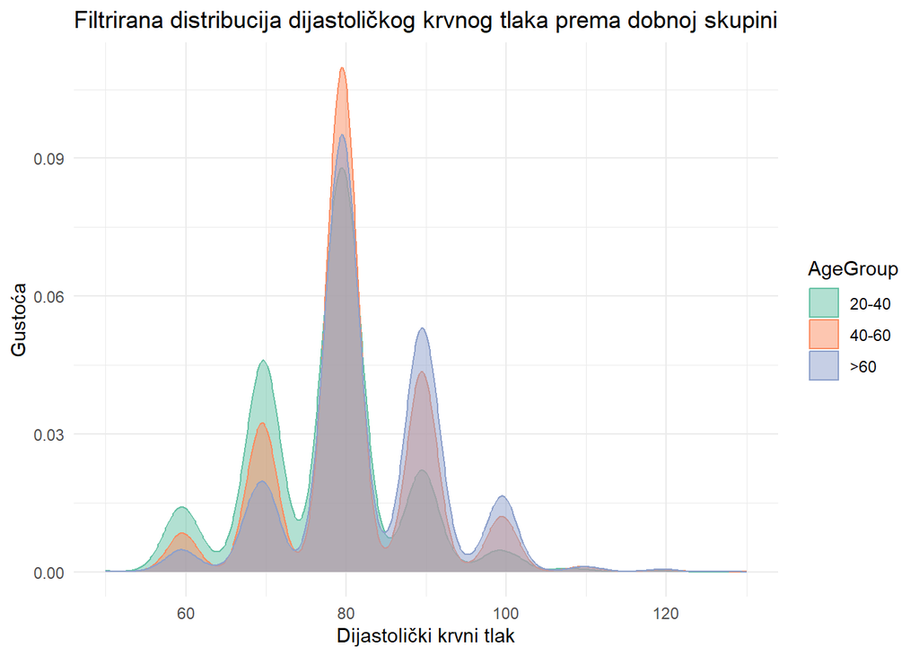

```r
ggplot(ap_filtered_data, aes(x = ap_lo, color = AgeGroup, fill = AgeGroup)) +
  geom_density(alpha = 0.5) +
  labs(title = "Filtrirana distribucija dijastoličkog krvnog tlaka prema dobnoj skupini",
       x = "Dijastolički krvni tlak",
       y = "Gustoća") +
  theme_minimal() +
  scale_fill_brewer(palette = "Set2") +
  scale_color_brewer(palette = "Set2")
```

#Zadatak 2

Testiramo postoji li statistički značajna razlika u prosječnim krvnim tlakovima kod pušača i kod nepušača.Pušenje je kategorijska varijabla (razlikujemo pušače i nepušače, a nema podataka o tome koliko često tko puši).

```r
data = healthDATA.modif
names(data)
summary(data$smoke)
```

```
##  [1] "...1"        "id"          "age"         "gender"      "height"
##  [6] "weight"      "ap_hi"       "ap_lo"       "cholesterol" "gluc"
## [11] "smoke"       "alco"        "active"      "cardio"      "AgeinYr"
## [16] "BMI"         "BMICat"      "AgeGroup"
##    Min. 1st Qu.  Median    Mean 3rd Qu.    Max.
## 0.00000 0.00000 0.00000 0.08818 0.00000 1.00000
```

Među podacima o krvnom tlaku ima besmislenih vrijednosti, poput negativnih brojeva ili jako niskih tlakova.

```r
data$ap_hi[data$ap_hi < 30]
```

```
##   [1]   14   14   11   12   14   11   14   12   14   12   10   16   12   14   12
##  [16]   12   12   11   12   12   12   12 -100   12   11    7   11   15   12   17
##  [31]   16    1   13   12   15   11   12   12   11   14   12   12   12   12   14
##  [46] -115   13   12   20   12   12   12   11   12   15   12 -100   12   10   12
##  [61]   12   14   11 -140   12   12   15   13   20 -120   12   14   14   14   16
##  [76]   12   12   14   11   12   14   12   12   14   10   11   13   12   12   11
##  [91]   20   11   11   14   12   11   12   12   11 -150   14   11   14   20   15
## [106]   11   11   12   11   14   11   11   11    1   14   12   11   12   12   13
## [121]   12   14   13   12 -120   12   12   14   12   13   14   12   11   12   11
## [136]   12   13   12   12   13   15   24   14   13   12   15   12   12   12   13
## [151]   12   17   10   14   17   12   10   12   12   14   15   15   15   12   15
## [166]   13   12   10   12   12   12   13   12   11   12   13   10   14   11   12
## [181]   15   12   12   12   14   14   12   13
```

Zato eliminiramo sve uzorke u kojima je zabilježen gornji (sistolički) tlak ispod 30 mmHg.

```r
ok = which(data$ap_hi >= 30)
data2 = data[ok,]
summary(data2$ap_hi)
```

```
##    Min. 1st Qu.  Median    Mean 3rd Qu.    Max.
##      60     120     120     127     140     240
```

Tlakove pušača i nepušača možemo prvo usporediti grafički pomoću box plotova. Imamo oko 6100 pušača i 63000 nepušača nakon eliminacije besmislenih vrijednosti, što znači da kasnije u testiranju možemo koristiti CGT. Vidimo da plotovi izgledaju dosta slično. I dalje postoji dosta outliera, pogotovo s visokim tlakom, ali nema ih smisla odbaciti kao pogrešna mjerenja jer je najveći tlak 240, što je sasvim moguće imati.

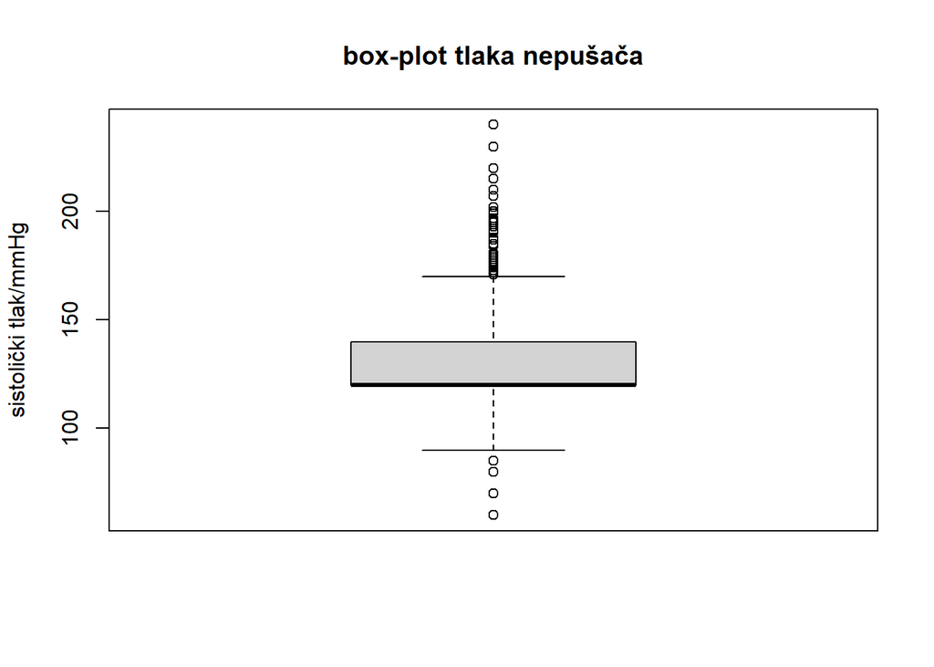

```r
pusaci = data2[data2["smoke"]==1,]
nepusaci = data2[data2["smoke"]==0,]

boxplot(nepusaci$ap_hi,
        main='box-plot tlaka nepušača',
        ylab='sistolički tlak/mmHg')
```

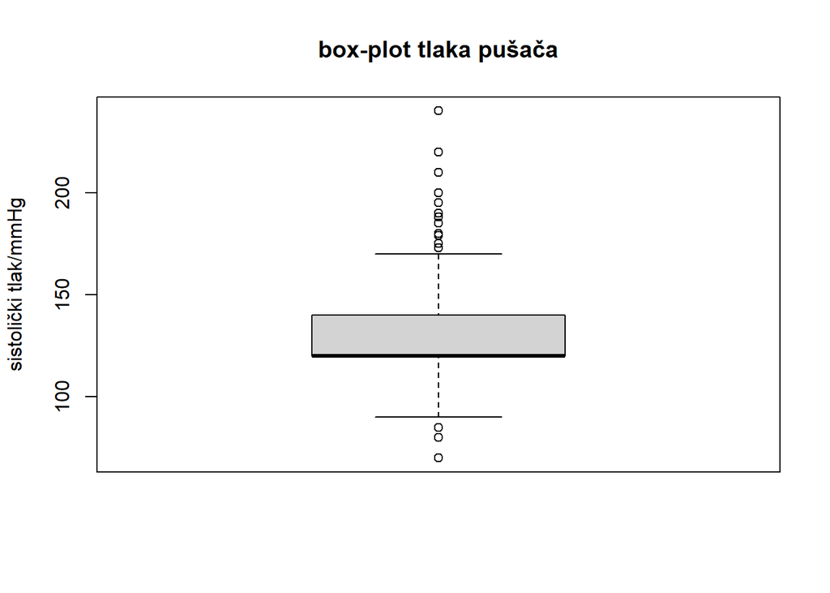

```r
boxplot(pusaci$ap_hi,
        main='box-plot tlaka pušača',
        ylab='sistolički tlak/mmHg')
```

```r
nrow(pusaci)
nrow(nepusaci)
```

```
## [1] 6160
## [1] 63612
```

Najprije provjeravama jesu li podaci iz normalne razdiobe. Kako ne znamo koju konkretnu normalnu razdiobu očekujemo, koristimo Lillieforsov test. Posebno testiramo tlakove pušača i nepušača. Također radimo Q-Q plotove za vizualnu usporedbu.

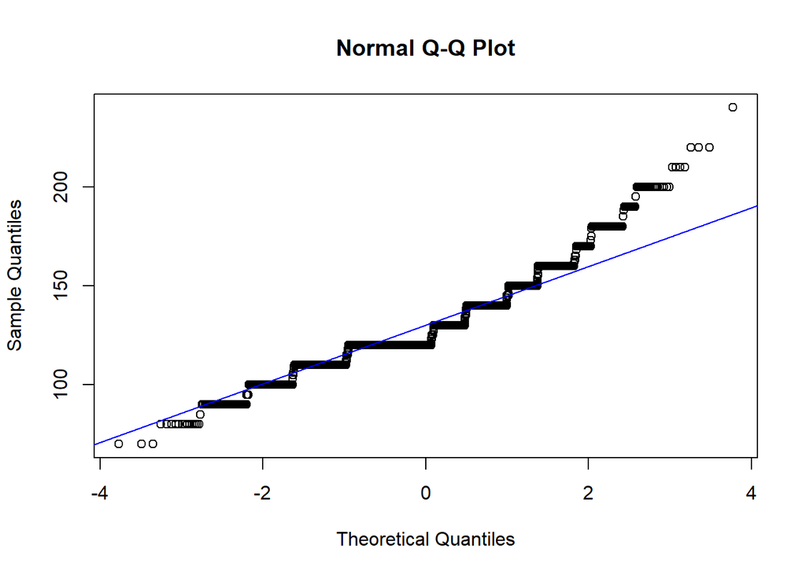

```r
lillie.test(pusaci$ap_hi)
lillie.test(nepusaci$ap_hi)
qqnorm(pusaci$ap_hi)
qqline(pusaci$ap_hi, col="blue")
```

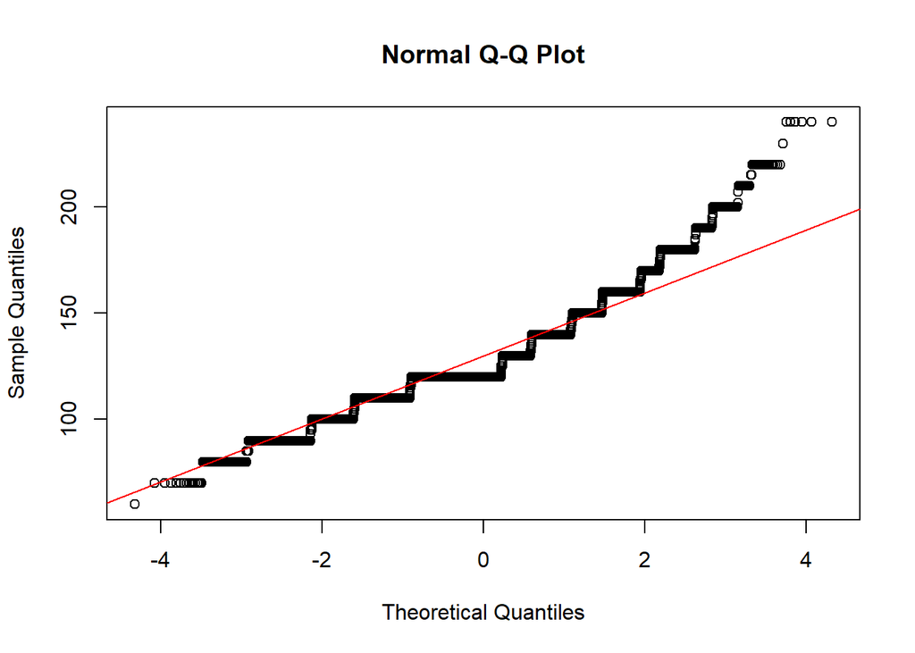

```
##
##  Lilliefors (Kolmogorov-Smirnov) normality test
##
## data:  pusaci$ap_hi
## D = 0.21037, p-value < 2.2e-16
##
##
##  Lilliefors (Kolmogorov-Smirnov) normality test
##
## data:  nepusaci$ap_hi
## D = 0.24289, p-value < 2.2e-16
```

```r
qqnorm(nepusaci$ap_hi)
qqline(nepusaci$ap_hi, col="red")
```

Test odbacuje nul-hipotezu (da su podaci slučajan uzorak iz normalne razdiobe) za obje grupe. Na Q-Q plotovima vidimo da distribucija podataka relativno dobro prati normalnu osim što ima vrlo teški rep prema većim vrijednostima, što je u skladu s prisutnošću mnogo outliera vidljivih u tom području na box plotu. Također uočavamo da su mjerenja zaokruživana pri unosu podataka.

Treba provjeriti jesu li varijance grupa jednake. To radimo F-testom. Dobivamo vrlo malu p-vrijednost, pa odbacujemo hipotezu o jednskosti varijance. Pušači imaju statistički značajno veću varijancu u sistoličkom tlaku nego nepušači.

```r
var.test(nepusaci$ap_hi, pusaci$ap_hi)
```

```
##
##  F test to compare two variances
##
## data:  nepusaci$ap_hi and pusaci$ap_hi
## F = 0.90174, num df = 63611, denom df = 6159, p-value = 2.641e-08
## alternative hypothesis: true ratio of variances is not equal to 1
## 95 percent confidence interval:
##  0.8687488 0.9354598
## sample estimates:
## ratio of variances
##          0.9017449
```

Testiramo hipotezu o jednakosti prosječnih krvnih tlakova u obje grupe koristeći T test uz nepoznate i varijance. Ne uzimamo pretpostavku da su varijance jednake zbog rezultata prethodnih testova.

```r
t.test(data2[data2["smoke"]==0,]$ap_hi, data2[data2["smoke"]==1,]$ap_hi, alternative = "two.sided", mu = 0, paired = FALSE, var.equal = FALSE, conf.level = 0.95)
```

```
##
##  Welch Two Sample t-test
##
## data:  data2[data2["smoke"] == 0, ]$ap_hi and data2[data2["smoke"] == 1, ]$ap_hi
## t = -7.0544, df = 7276.2, p-value = 1.893e-12
## alternative hypothesis: true difference in means is not equal to 0
## 95 percent confidence interval:
##  -2.145172 -1.212214
## sample estimates:
## mean of x mean of y
##  126.8536  128.5323
```

P vrijednost je vrlo mala pa možemo odbaciti hipotezu o jednakosti srednjih vrijednosti sistoličkih tlakova na razini značajnosti od 5%. Međutim, iako test pokazuje statistički značajnu razliku, procijenjene sredine su vrlo malo udaljene pa u praksi utjecaj pušenja na krvni tlak vjerojatno nije značajan.

#Zadatak 3

```r
# Učitavanje podataka iz csv datoteke:
healthDATA.modif = read.csv("Health Screening Data.csv")
View(healthDATA.modif)
```

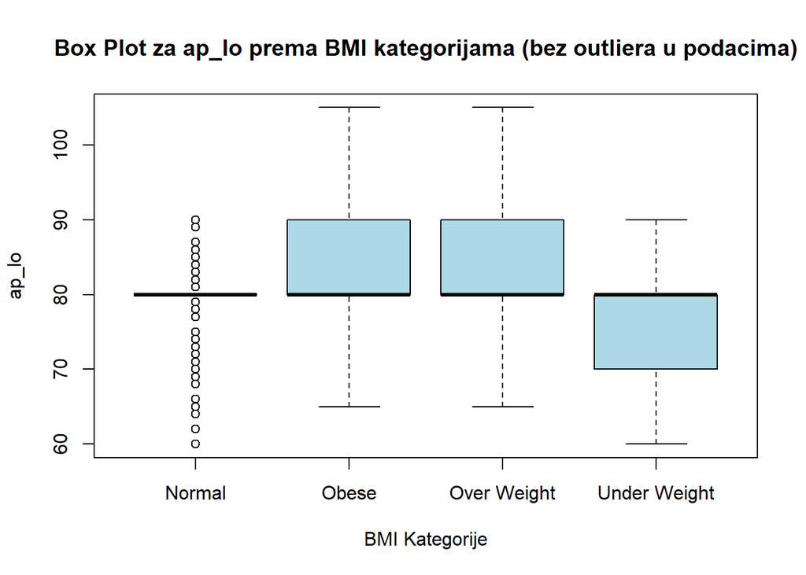

```r
# Funkcija za uklanjanje outliera
remove_outliers <- function(x) {
  Q1 <- quantile(x, 0.25, na.rm = TRUE)
  Q3 <- quantile(x, 0.75, na.rm = TRUE)
  IQR <- Q3 - Q1
  lower <- Q1 - 1.5 * IQR
  upper <- Q3 + 1.5 * IQR
  x[x >= lower & x <= upper]
}

# Filtriranje podataka za ap_lo i ap_hi:
healthDATA.filtered <- healthDATA.modif %>%
  group_by(BMICat) %>%
  filter(ap_lo >= quantile(ap_lo, 0.25) - 1.5 * IQR(ap_lo) &
           ap_lo <= quantile(ap_lo, 0.75) + 1.5 * IQR(ap_lo)) %>%
  filter(ap_hi >= quantile(ap_hi, 0.25) - 1.5 * IQR(ap_hi) &
           ap_hi <= quantile(ap_hi, 0.75) + 1.5 * IQR(ap_hi))


# Generiranje box plotova bez outliera:
boxplot(ap_lo ~ BMICat,
        data = healthDATA.filtered,
        main = "Box Plot za ap_lo prema BMI kategorijama (bez outliera u podacima)",
        xlab = "BMI Kategorije",
        ylab = "ap_lo",
        col = "lightblue")
```

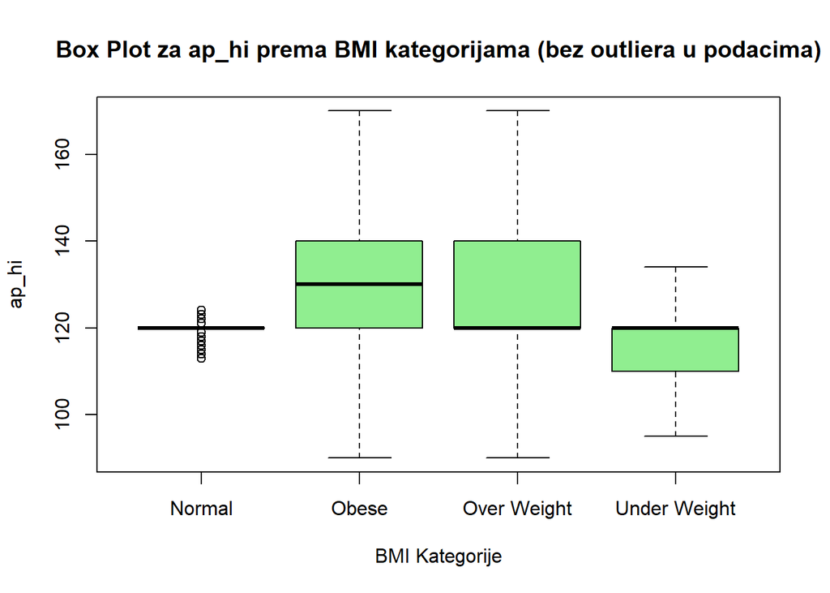

```r
boxplot(ap_hi ~ BMICat,
        data = healthDATA.filtered,
        main = "Box Plot za ap_hi prema BMI kategorijama (bez outliera u podacima)",
        xlab = "BMI Kategorije",
        ylab = "ap_hi",
        col = "lightgreen")
```

Izračun prosječnih vrijedosti po tablici

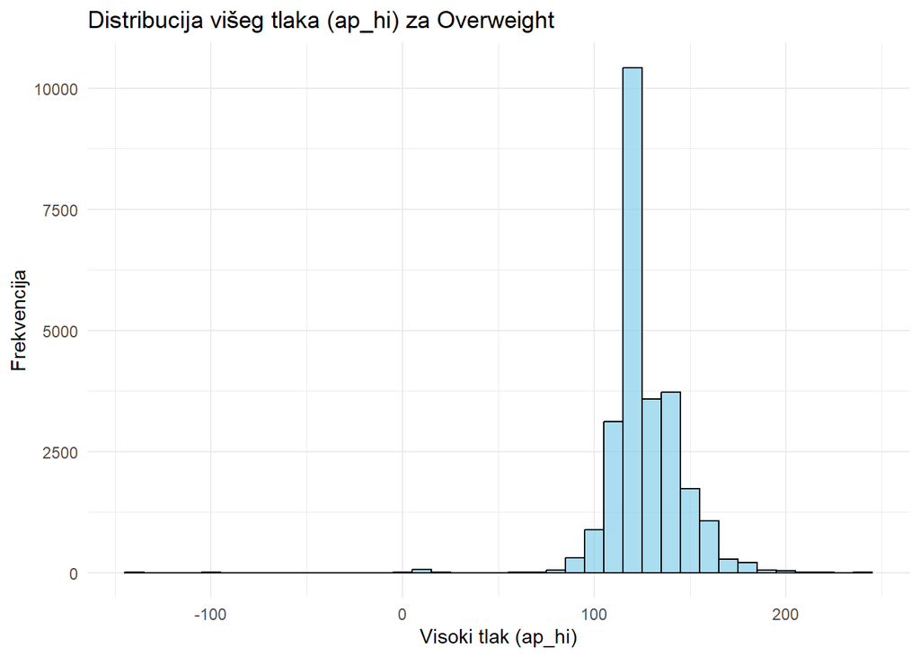

```r
# Filtriranje podataka za kategoriju "Overweight":
overweight_data <- healthDATA.modif %>%
  filter(BMICat == "Over Weight")

# Histogram distribucije ap_hi za Overweight:
ggplot(overweight_data, aes(x = ap_hi)) +
  geom_histogram(binwidth = 10, fill = "skyblue", color = "black", alpha = 0.7) +
  labs(title = "Distribucija višeg tlaka (ap_hi) za Overweight",
       x = "Visoki tlak (ap_hi)",
       y = "Frekvencija") +
  theme_minimal()
```

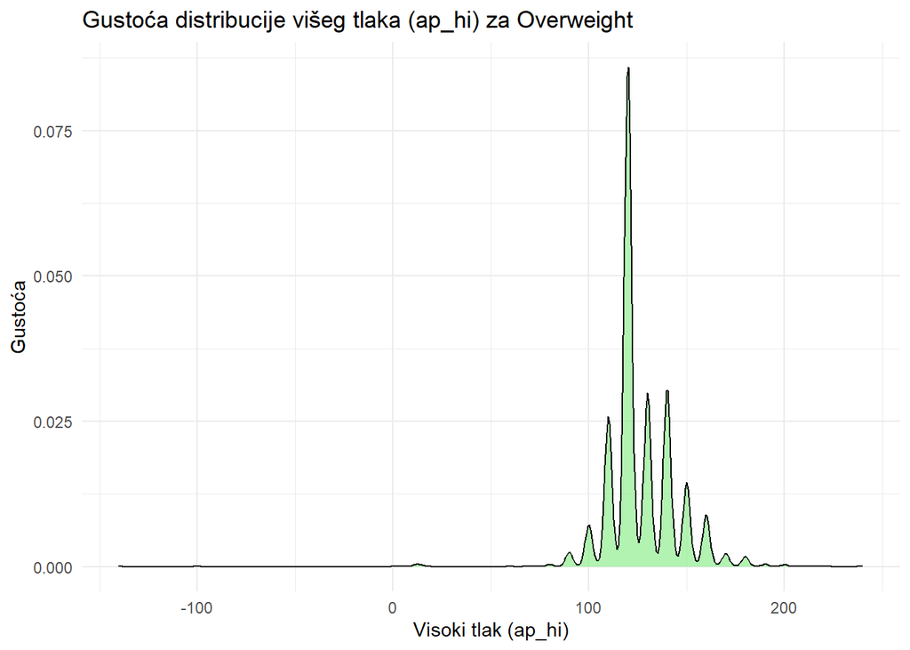

```r
# Density graf distribucije ap_hi za Overweight:
ggplot(overweight_data, aes(x = ap_hi)) +
  geom_density(fill = "lightgreen", alpha = 0.7) +
  labs(title = "Gustoća distribucije višeg tlaka (ap_hi) za Overweight",
       x = "Visoki tlak (ap_hi)",
       y = "Gustoća") +
  theme_minimal()
```

```r
# Filtriranje podataka za kategoriju "Overweight":
overweight_data <- healthDATA.modif %>%
  filter(BMICat == "Over Weight")

# Izračun kvartila za ap_hi:
quartiles <- quantile(overweight_data$ap_hi, probs = c(0.25, 0.5, 0.75, 1.0), na.rm = TRUE)

# Ispis rezultata:
print(quartiles)
```

```
##  25%  50%  75% 100%
##  120  120  140  240
```

```r
# Funkcija za uklanjanje outliera:
remove_outliers <- function(x) {
  Q1 <- quantile(x, 0.25, na.rm = TRUE)
  Q3 <- quantile(x, 0.75, na.rm = TRUE)
  IQR <- Q3 - Q1
  lower <- Q1 - 1.5 * IQR
  upper <- Q3 + 1.5 * IQR
  return(x[x >= lower & x <= upper])
}

# Filtriranje podataka za kategoriju "Overweight":
overweight_data <- healthDATA.modif %>%
  filter(BMICat == "Over Weight")

# Uklanjanje outliera iz ap_hi:
filtered_ap_hi <- remove_outliers(overweight_data$ap_hi)

# Tablica frekvencija za ap_hi bez outliera:
freq_table <- as.data.frame(table(filtered_ap_hi))

# Dodavanje naziva stupaca:
colnames(freq_table) <- c("Vrijednost_ap_hi", "Frekvencija")

# Ispis tablice frekvencija:
print(freq_table)
```

```
##    Vrijednost_ap_hi Frekvencija
## 1                90         289
## 2                95          11
## 3                96           1
## 4               100         849
## 5               101           1
## 6               102           2
## 7               103           3
## 8               104           1
## 9               105          28
## 10              106           2
## 11              107           3
## 12              108           3
## 13              109           2
## 14              110        2995
```

[output cut: 60 more lines]

```r
# Izračun srednje vrijednosti za sve podatke (sve BMI grupe zajedno) za ap_hi i ap_lo:
srednja_sve <- healthDATA.modif %>%
  summarise(Srednja_ap_hi = mean(ap_hi, na.rm = TRUE),
            Srednja_ap_lo = mean(ap_lo, na.rm = TRUE))

# Izračun srednje vrijednosti za svaku BMI grupu odvojeno za ap_hi i ap_lo:
srednja_po_grupama <- healthDATA.modif %>%
  group_by(BMICat) %>%
  summarise(Srednja_ap_hi = mean(ap_hi, na.rm = TRUE),
            Srednja_ap_lo = mean(ap_lo, na.rm = TRUE))

# Ispis rezultata:
cat("Srednje vrijednosti za sve BMI grupe zajedno:\n")
print(srednja_sve)

cat("\nSrednje vrijednosti za svaku BMI grupu odvojeno:\n")
print(srednja_po_grupama)
```

```
## Srednje vrijednosti za sve BMI grupe zajedno:
##   Srednja_ap_hi Srednja_ap_lo
## 1      126.6811      96.64764
##
## Srednje vrijednosti za svaku BMI grupu odvojeno:
## # A tibble: 4 × 3
##   BMICat       Srednja_ap_hi Srednja_ap_lo
##   <chr>                <dbl>         <dbl>
## 1 Normal                122.          88.9
## 2 Obese                 133.         107.
## 3 Over Weight           127.          97.1
## 4 Under Weight          116.          81.3
```

```r
# Provjera veličine svake BMI grupe
velicine_grupa <- healthDATA.modif %>%
  group_by(BMICat) %>%
  summarise(Velicina = n())

cat("Veličine BMI grupa:\n")
print(velicine_grupa)

# Kolmogorov-Smirnov test za normalnost za svaku grupu i za ap_hi i ap_lo
ks_test_rezultati <- healthDATA.modif %>%
  group_by(BMICat) %>%
  summarise(
    KS_ap_hi_stat = ks.test(ap_hi, "pnorm", mean(ap_hi, na.rm = TRUE), sd(ap_hi, na.rm = TRUE))$statistic,
    KS_ap_hi_pval = ks.test(ap_hi, "pnorm", mean(ap_hi, na.rm = TRUE), sd(ap_hi, na.rm = TRUE))$p.value,
    KS_ap_lo_stat = ks.test(ap_lo, "pnorm", mean(ap_lo, na.rm = TRUE), sd(ap_lo, na.rm = TRUE))$statistic,
    KS_ap_lo_pval = ks.test(ap_lo, "pnorm", mean(ap_lo, na.rm = TRUE), sd(ap_lo, na.rm = TRUE))$p.value
  )
cat("\nKolmogorov-Smirnov test rezultati:\n")
print(ks_test_rezultati)
```

```
## Veličine BMI grupa:
## # A tibble: 4 × 2
##   BMICat       Velicina
##   <chr>           <int>
## 1 Normal          25198
## 2 Obese           18602
## 3 Over Weight     25533
## 4 Under Weight      627
##
## Kolmogorov-Smirnov test rezultati:
## # A tibble: 4 × 5
##   BMICat       KS_ap_hi_stat KS_ap_hi_pval KS_ap_lo_stat KS_ap_lo_pval
##   <chr>                <dbl>         <dbl>         <dbl>         <dbl>
## 1 Normal               0.278             0         0.460             0
## 2 Obese                0.141             0         0.472             0
## 3 Over Weight          0.225             0         0.470             0
## 4 Under Weight         0.210             0         0.415             0
```

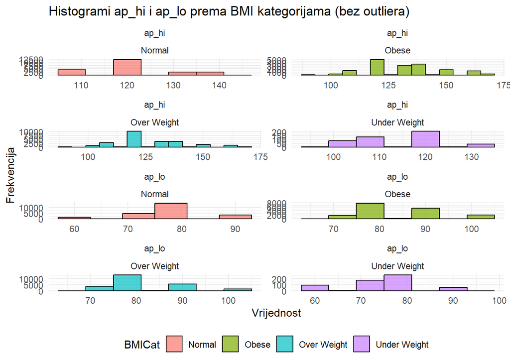

```r
# Funkcija za uklanjanje outliera:
remove_outliers <- function(x) {
  Q1 <- quantile(x, 0.25, na.rm = TRUE)
  Q3 <- quantile(x, 0.75, na.rm = TRUE)
  IQR <- Q3 - Q1
  lower <- Q1 - 1.5 * IQR
  upper <- Q3 + 1.5 * IQR
  return(ifelse(x >= lower & x <= upper, x, NA))
}

# Uklanjanje outliera za ap_hi i ap_lo:
zd3_filtered_data <- healthDATA.modif %>%
  group_by(BMICat) %>%
  mutate(ap_hi_filtered = remove_outliers(ap_hi),
         ap_lo_filtered = remove_outliers(ap_lo)) %>%
  ungroup()

# Priprema podataka za grafove:
ap_hi_data <- zd3_filtered_data %>%
  select(BMICat, ap_hi_filtered) %>%
  rename(Value = ap_hi_filtered) %>%
  mutate(Variable = "ap_hi")

ap_lo_data <- zd3_filtered_data %>%
  select(BMICat, ap_lo_filtered) %>%
  rename(Value = ap_lo_filtered) %>%
  mutate(Variable = "ap_lo")

# Kombiniranje podataka:
plot_data <- bind_rows(ap_hi_data, ap_lo_data)

# Kreiranje histogram grafova s facet_wrap:
ggplot(plot_data, aes(x = Value, fill = BMICat)) +
  geom_histogram(binwidth = 6, color = "black", alpha = 0.7, position = "dodge") +
  facet_wrap(~ Variable + BMICat, scales = "free", ncol = 2) +
  labs(title = "Histogrami ap_hi i ap_lo prema BMI kategorijama (bez outliera)",
       x = "Vrijednost",
       y = "Frekvencija") +
  theme_minimal() +
  theme(legend.position = "bottom")
```

[figure not shown]

```r
# Funkcija za zaokruživanje na najbliži višekratnik 5:
round_to_nearest_5 <- function(x) {
  round(x / 10) * 10
}

# Funkcija za uklanjanje outliera:
remove_outliers <- function(x) {
  Q1 <- quantile(x, 0.25, na.rm = TRUE)
  Q3 <- quantile(x, 0.75, na.rm = TRUE)
  IQR <- Q3 - Q1
  lower <- Q1 - 1.5 * IQR
  upper <- Q3 + 1.5 * IQR
  return(ifelse(x >= lower & x <= upper, x, NA))
}

# Uklanjanje outliera i zaokruživanje:
zd3_filtered_data <- healthDATA.modif %>%
  group_by(BMICat) %>%
  mutate(
    ap_hi = remove_outliers(ap_hi), # Ukloni outliere za ap_hi
    ap_lo = remove_outliers(ap_lo), # Ukloni outliere za ap_lo
    ap_hi = round_to_nearest_5(ap_hi), # Zaokruži na 5
    ap_lo = round_to_nearest_5(ap_lo)  # Zaokruži na 5
  ) %>%
  ungroup()

# Histogrami za ap_hi:
hist_ap_hi <- ggplot(zd3_filtered_data, aes(x = ap_hi)) +
  geom_histogram(binwidth = 5, color = "black", fill = "lightblue", alpha = 0.7) +
  facet_wrap(~ BMICat, scales = "free_y", ncol = 2) +
  labs(title = "Histograms for ap_hi (Rounded, Outliers Removed)",
       x = "ap_hi (Rounded to 5)",
       y = "Frequency") +
  theme_minimal()

# Histogrami za ap_lo:
hist_ap_lo <- ggplot(zd3_filtered_data, aes(x = ap_lo)) +
  geom_histogram(binwidth = 5, color = "black", fill = "lightgreen", alpha = 0.7) +
  facet_wrap(~ BMICat, scales = "free_y", ncol = 2) +
  labs(title = "Histograms for ap_lo (Rounded, Outliers Removed)",
       x = "ap_lo (Rounded to 5)",
       y = "Frequency") +
  theme_minimal()

# Q-Q grafovi za ap_hi:
qq_ap_hi <- ggplot(zd3_filtered_data, aes(sample = ap_hi)) +
  stat_qq() +
  stat_qq_line() +
  facet_wrap(~ BMICat, scales = "free", ncol = 2) +
  labs(title = "Q-Q Plots for ap_hi (Rounded, Outliers Removed)",
       x = "Theoretical Quantiles",
       y = "Sample Quantiles") +
  theme_minimal()

# Q-Q grafovi za ap_lo:
qq_ap_lo <- ggplot(zd3_filtered_data, aes(sample = ap_lo)) +
  stat_qq() +
  stat_qq_line() +
  facet_wrap(~ BMICat, scales = "free", ncol = 2) +
  labs(title = "Q-Q Plots for ap_lo (Rounded, Outliers Removed)",
       x = "Theoretical Quantiles",
       y = "Sample Quantiles") +
  theme_minimal()

# Prikaz svih grafova:
print(hist_ap_hi)
```

[figure not shown]

```r
print(hist_ap_lo)
```

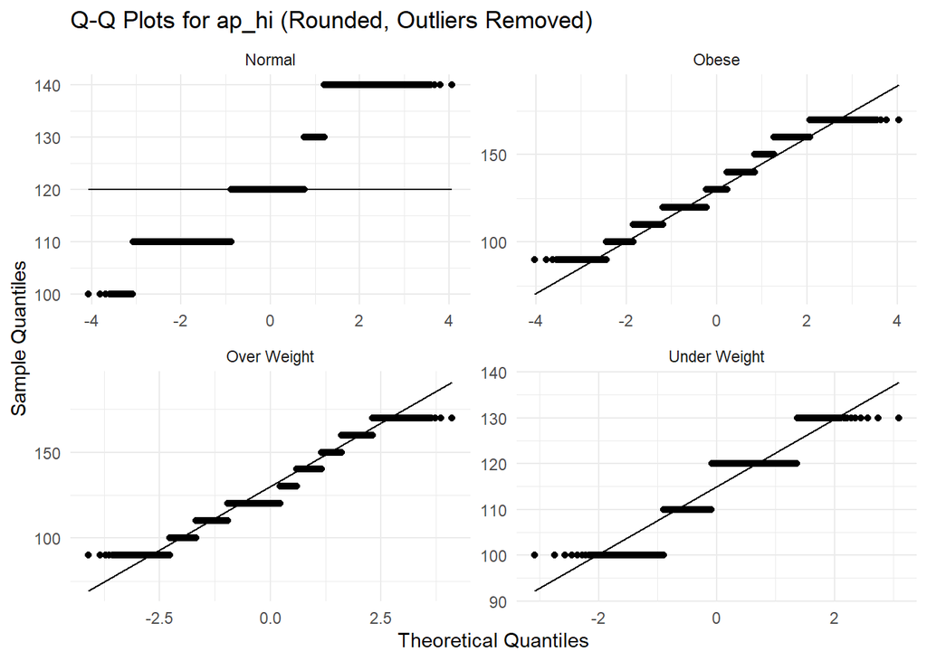

```r
print(qq_ap_hi)
```

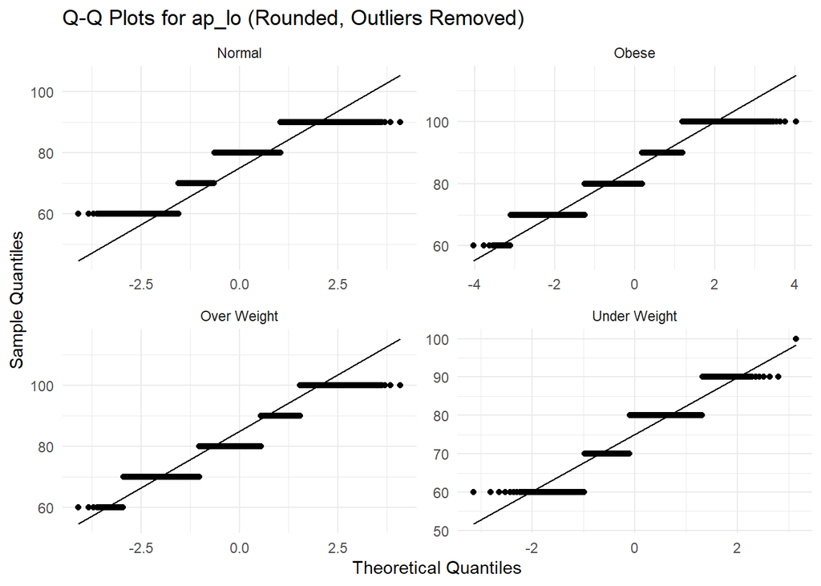

```r
print(qq_ap_lo)
```

```r
# Funkcija za zaokruživanje na najbliži višekratnik 10:
round_to_nearest_10 <- function(x) {
  round(x / 10) * 10
}

# Funkcija za uklanjanje outliera:
remove_outliers <- function(x) {
  Q1 <- quantile(x, 0.25, na.rm = TRUE)
  Q3 <- quantile(x, 0.75, na.rm = TRUE)
  IQR <- Q3 - Q1
  lower <- Q1 - 1.5 * IQR
  upper <- Q3 + 1.5 * IQR
  return(ifelse(x >= lower & x <= upper, x, NA))
}

# Uklanjanje outliera i zaokruživanje na 10:
zd3_filtered_data <- healthDATA.modif %>%
  group_by(BMICat) %>%
  mutate(
    ap_hi = remove_outliers(ap_hi), # Ukloni outliere za ap_hi
    ap_lo = remove_outliers(ap_lo), # Ukloni outliere za ap_lo
    ap_hi = round_to_nearest_10(ap_hi), # Zaokruži na 10
    ap_lo = round_to_nearest_10(ap_lo)  # Zaokruži na 10
  ) %>%
  ungroup()

# Provjera normalnosti za diskretne vrijednosti:
ks_results_rounded_10 <- zd3_filtered_data %>%
  group_by(BMICat) %>%
  summarise(
    KS_ap_hi_stat = ks.test(ap_hi, "pnorm", mean(ap_hi, na.rm = TRUE), sd(ap_hi, na.rm = TRUE))$statistic,
    KS_ap_hi_pval = ks.test(ap_hi, "pnorm", mean(ap_hi, na.rm = TRUE), sd(ap_hi, na.rm = TRUE))$p.value,
    KS_ap_lo_stat = ks.test(ap_lo, "pnorm", mean(ap_lo, na.rm = TRUE), sd(ap_lo, na.rm = TRUE))$statistic,
    KS_ap_lo_pval = ks.test(ap_lo, "pnorm", mean(ap_lo, na.rm = TRUE), sd(ap_lo, na.rm = TRUE))$p.value
  )
```

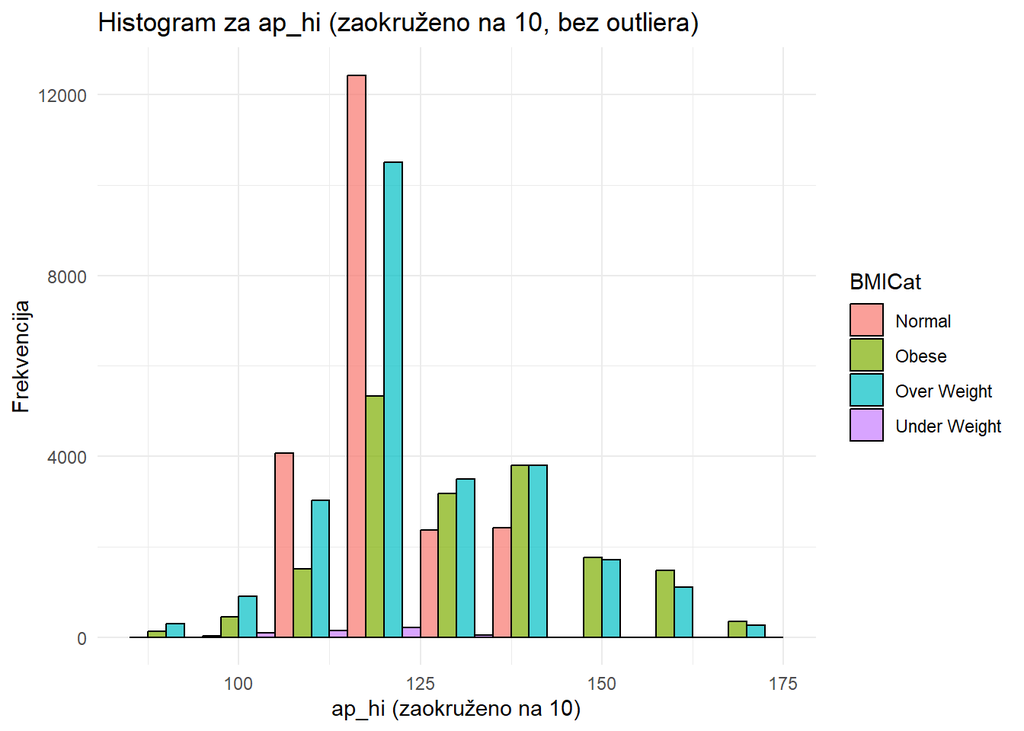

```r
# Histogrami za ap_hi i ap_lo:
hist_ap_hi_10 <- ggplot(zd3_filtered_data, aes(x = ap_hi, fill = BMICat)) +
  geom_histogram(binwidth = 10, color = "black", alpha = 0.7, position = "dodge") +
  labs(title = "Histogram za ap_hi (zaokruženo na 10, bez outliera)",
       x = "ap_hi (zaokruženo na 10)",
       y = "Frekvencija") +
  theme_minimal()

hist_ap_lo_10 <- ggplot(zd3_filtered_data, aes(x = ap_lo, fill = BMICat)) +
  geom_histogram(binwidth = 10, color = "black", alpha = 0.7, position = "dodge") +
  labs(title = "Histogram za ap_lo (zaokruženo na 10, bez outliera)",
       x = "ap_lo (zaokruženo na 10)",
       y = "Frekvencija") +
  theme_minimal()

# Prikaz rezultata Kolmogorov-Smirnovog testa:
cat("\nKolmogorov-Smirnov test za normalnost (zaokružene varijable na 10, bez outliera):\n")
print(ks_results_rounded_10)

# Prikaz histogram grafova:
print(hist_ap_hi_10)
```

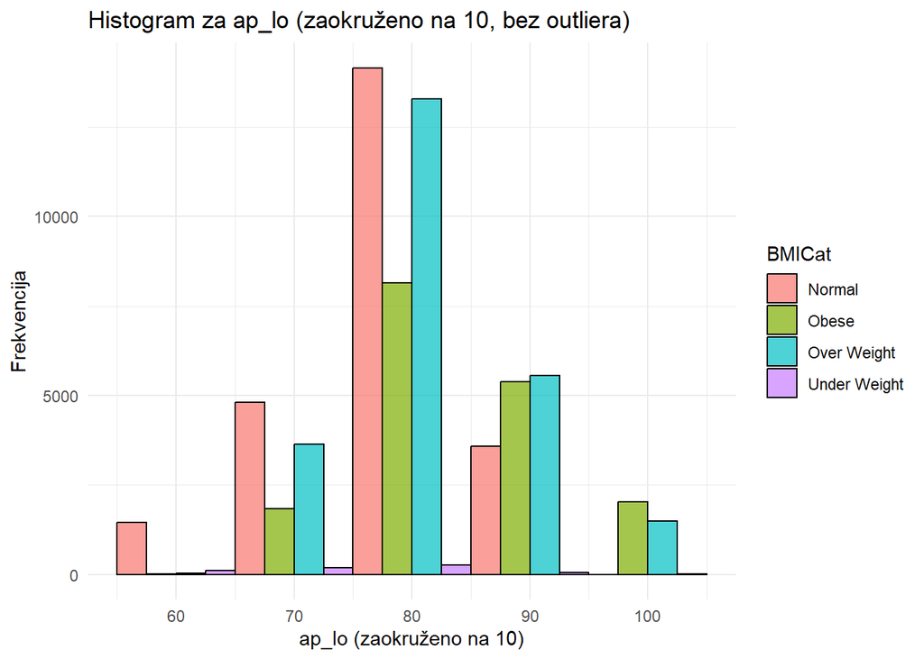

```
##
## Kolmogorov-Smirnov test za normalnost (zaokružene varijable na 10, bez outliera):
## # A tibble: 4 × 5
##   BMICat       KS_ap_hi_stat KS_ap_hi_pval KS_ap_lo_stat KS_ap_lo_pval
##   <chr>                <dbl>         <dbl>         <dbl>         <dbl>
## 1 Normal               0.342             0         0.330             0
## 2 Obese                0.177             0         0.273             0
## 3 Over Weight          0.253             0         0.309             0
## 4 Under Weight         0.271             0         0.265             0
```

```r
print(hist_ap_lo_10)
```

```r
# Leveneov test za ap_hi:
levene_ap_hi <- leveneTest(ap_hi ~ BMICat, data = zd3_filtered_data, na.action = na.exclude)
# Leveneov test za ap_lo:
levene_ap_lo <- leveneTest(ap_lo ~ BMICat, data = zd3_filtered_data, na.action = na.exclude)
# Prikaz rezultata:
cat("Rezultati Leveneovog testa za ap_hi:\n")
print(levene_ap_hi)

cat("\nRezultati Leveneovog testa za ap_lo:\n")
print(levene_ap_lo)
```

```
## Rezultati Leveneovog testa za ap_hi:
## Levene's Test for Homogeneity of Variance (center = median: na.exclude)
##          Df F value    Pr(>F)
## group     3  2188.9 < 2.2e-16 ***
##       64861
## ---
## Signif. codes:  0 '***' 0.001 '**' 0.01 '*' 0.05 '.' 0.1 ' ' 1
##
## Rezultati Leveneovog testa za ap_lo:
## Levene's Test for Homogeneity of Variance (center = median: na.exclude)
##          Df F value    Pr(>F)
## group     3  303.15 < 2.2e-16 ***
##       66028
## ---
## Signif. codes:  0 '***' 0.001 '**' 0.01 '*' 0.05 '.' 0.1 ' ' 1
```

#Zadatak 4